# ccc

Pierre Nouvellet

2019-07

NEED to do: 1) input

# Input

```r
date_week_finishing <-  as.Date('29/03/2020',format = '%d/%m/%Y')
# delay_report_death <- 10 # need checking!!
mu_delta <- 10
s_delta <- 2

day.project <- 7
t.window.range <- 7

rep <- 2e4
```

# Read data

```r
d <- readRDS(file = paste0('../Team.input/data_',date_week_finishing,'.rds'))

D <- d$D_active_transmission
I <- d$I_active_transmission
country <- d$Country
N_geo <- length(country)
# date_week_finishing <- d$date_week_finishing
```

# framework

We assume that the delay between repoted death to reported case follow a Gamma distribution with mean $\mu_{\delta}$ and standard deviation $\sigma_{\delta}$ :
$$delta \sim \Gamma\left(\mu_{\delta},\sigma_{\delta}\right)$$

We define:

- $D_{i,t}$: the number of deaths on day $t$ in location $i$,
- $I^r_{i,t}$: the number of reported cases on day $t$ in location $i$,
- $I^T_{i,t}$: the number of ture cases on day $t$ in location $i$.

We are interested in estimating trends in reporting and case ascertainment. In all the analysis, we must account for the variation in the delay of reporting a case and death of that case. Formally we have:
$$E[D_{i,t}] = CFR \int_0^{+\infty} I^T_{i,t-x} \Gamma\left(x; \mu_{\delta},\sigma_{\delta}\right) dx$$

We first define the ratio, $r_{i,t}$ between reported deaths and reported cases, accounting for the delay between repoting and deaths. We can infer this ratio using the following:
$$D_{i,t} \sim Bin\left(\int_0^{+\infty} I^r_{i,t-x} \Gamma\left(x; \mu_{\delta},\sigma_{\delta}\right) dx ,r_{i,t-\mu_{\delta}}\right)$$
Case ascertainment, $\rho_{i,t}$ can defined as:
$$\rho_{i,t} = \frac{CFR}{r_{i,t}}$$

This case ascertainment rely on the assumption that all deaths are reported.

When we have no information on deaths, i.e. from $t-\mu_{\delta}$ onward, we use the posterior distribution of estimatedcase ascertainment, $\rho_{i,t}$ to obtain:
$$I^T_{i,t} \sim I^r_{i,t} + NBin\left(I^r_{i,t}, \rho_{i,t}\right)$$

# delay repot to death

```r
SI_gamma_dist_EpiEstim <- function(mu,si_std,SItrunc){
  SI_Distr <- EpiEstim::discr_si(seq(0, SItrunc), mu, si_std) # sapply(0:SItrunc, function(e) EpiEstim::DiscrSI(e,mu,mu*cv) )
  SI_Distr <- SI_Distr / sum(SI_Distr)
  return(list(dist = SI_Distr, SItrunc = SItrunc))
}


SItrunc <- 30

w_delta <- SI_gamma_dist_EpiEstim(mu = mu_delta, si_std = s_delta, SItrunc = SItrunc)
```

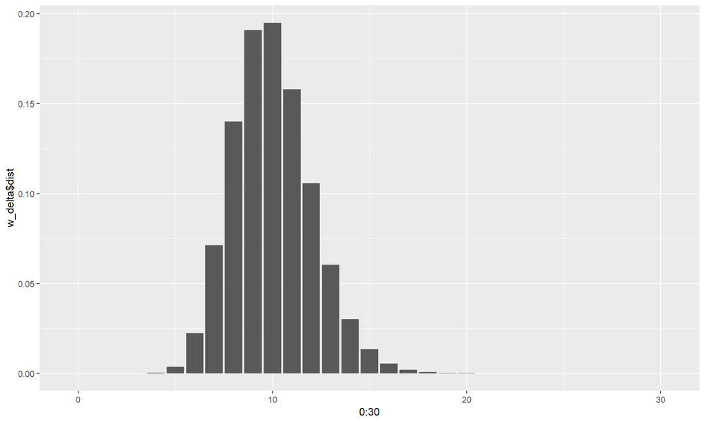

```r
library(ggplot2)
ggplot() + geom_col(aes(x = 0:30, y = w_delta$dist))
```

we pre-compute for each day and location:
$$\int_0^{+\infty} I^r_{i,t-x} \Gamma\left(x; \mu_{\delta},\sigma_{\delta}\right) dx$$

```r
weighted_I <- matrix(NA, nrow = nrow(I), ncol = N_geo)
ws <- rev(w_delta$dist)

for (i in 1:nrow(I)){
    f <- max(c(1,(i-w_delta$SItrunc)))
    weighted_I[i,] <- t(t(I[f:i,-1])%*%ws[((SItrunc+1)-(i-f)):(SItrunc+1)])

}
```

# ratio death to report

bayesian inference, with beta prior (0.5,0.5)

```r
library(binom)
n_post <- 1e4
# check posterior
# binconf(x = 5, n = 10, method = 'exact')
# hpd <- binom.bayes(
#   x = 5, n = 10.5, type = "central", conf.level = 0.95, tol = 1e-9)
# x <- rbeta(n = 1e4, shape1 = hpd$shape1, shape2 = hpd$shape2)
# c(mean(x), quantile(x,c(.025,.975)))
temp <- D
temp[,-1] <- NA
# do inference
r_it<-array(NA, dim = c(nrow(I), N_geo,n_post))
summary_r <- list(median = temp,
                        low = temp,
                        high = temp)


t.window <- 7

for (i in 1:nrow(I)){
  f <- seq(max(c(1,i-t.window+1)),i)

  for (j in 1:N_geo){

    if (sum(weighted_I[f,j]) > 0){

      hpd <- binom.bayes( x = sum(D[f,j+1]), n = sum(weighted_I[f,j]),
                          type = "central", conf.level = 0.95, tol = 1e-9)

      r_it[i,j,] <- rbeta(n = n_post, shape1 = hpd$shape1, shape2 = hpd$shape2)
      if (sum(D[f,j+1]) > sum(weighted_I[f,j])) r_it[i,j,] <- 1

      summary_r$median[i,j+1] <- median(r_it[i,j,],na.rm = TRUE)
      summary_r$low[i,j+1] <- quantile(r_it[i,j,],.025,na.rm = TRUE)
      summary_r$high[i,j+1] <- quantile(r_it[i,j,],.975,na.rm=TRUE)
    }
    # c(mean(x), quantile(x,c(.025,.975)))
  }
}
```

### plot ratio to death

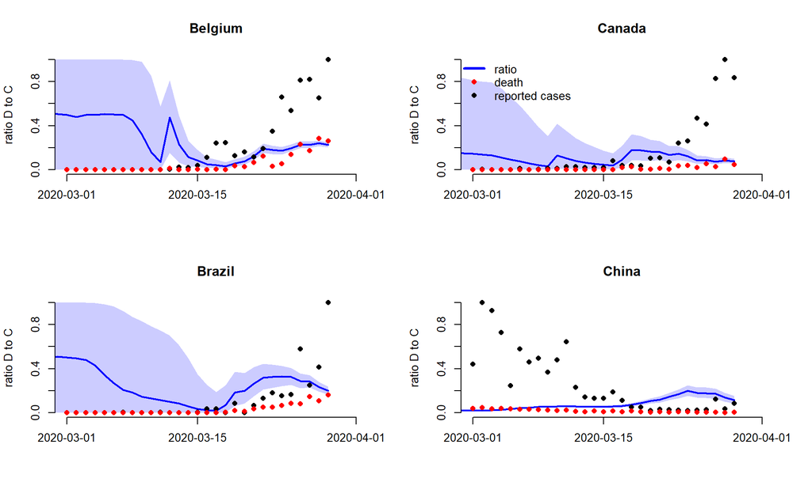

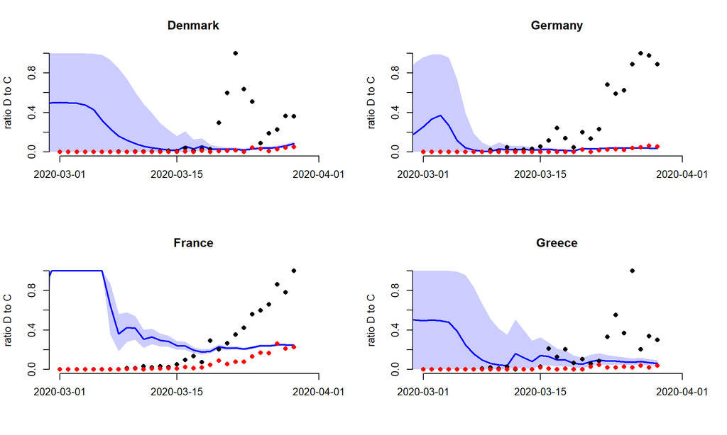

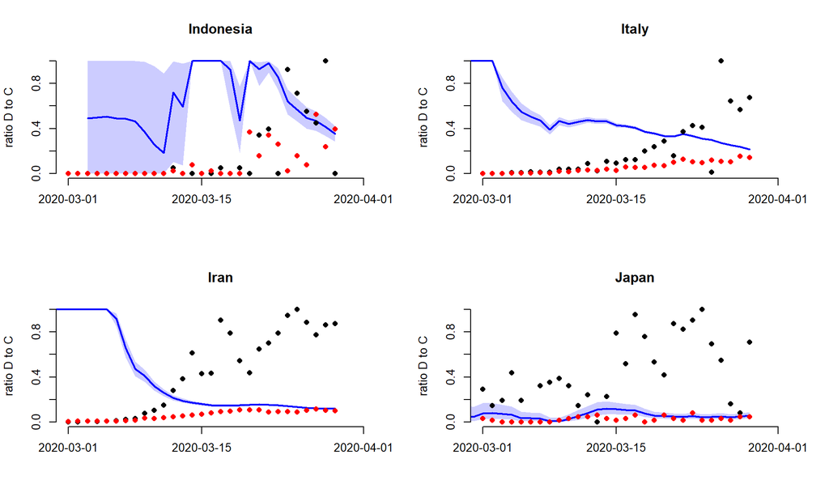

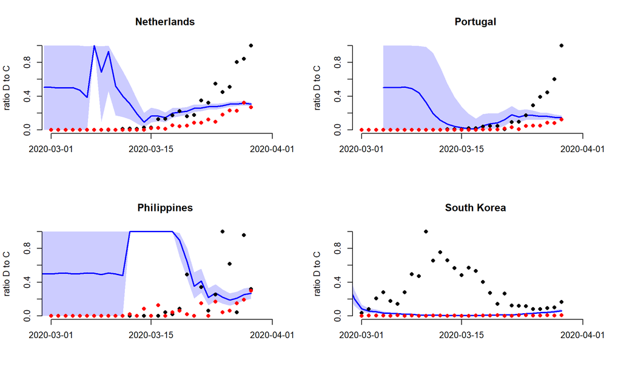

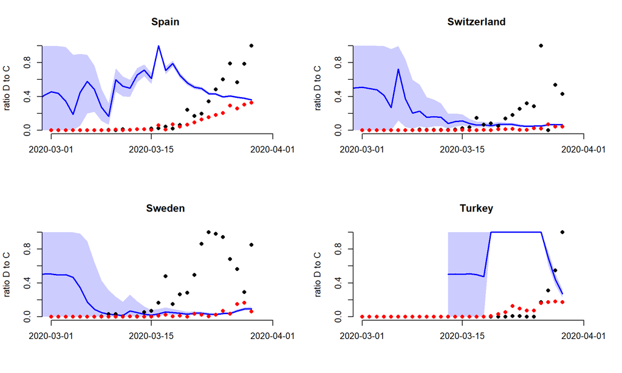

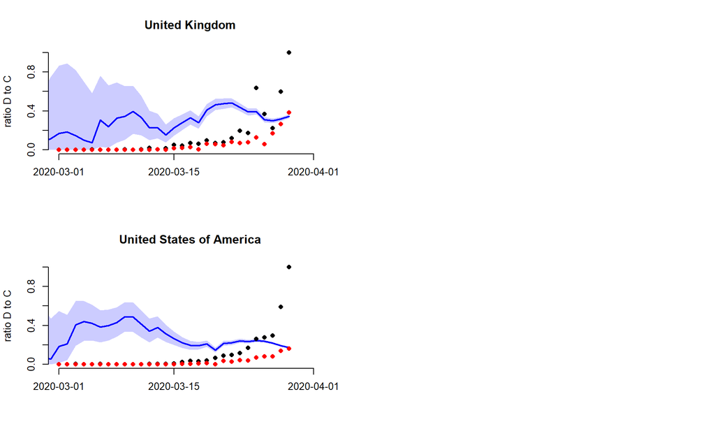

```r
f <- which(summary_r$median$dates >= as.Date(c('01/03/2020'),format = '%d/%m/%Y'))


layout(matrix(1:4,2,2))
for (i in 1:N_geo){
  plot(summary_r$median$dates,summary_r$median[,i+1],lwd = 2,
       #ylim = c(0,max(a[f,2:4],na.rm=TRUE)),
       ylim=c(0,1),
       type='l',
       xlim = c(as.Date(c('01/03/2020'),format = '%d/%m/%Y'),
                date_week_finishing+4),
       bty ='n',
       main = snakecase::to_any_case(country[i], case = "title"),
       col = rgb(0,0,1),
       xlab = '', ylab = 'ratio D to C',
       xaxt="n")
  axis(1, at=as.Date(c('2020-03-01','2020-03-15','2020-04-01'),format = '%Y-%m-%d'),
       labels = c('2020-03-01','2020-03-15','2020-04-01'),las=1)

  polygon(c(summary_r$median$dates,rev(summary_r$median$dates)),
          c(summary_r$low[,i+1],rev(summary_r$high[,i+1])),
          border = NA,
          col = rgb(0,0,1,0.2))
  f2 <- which( I$dates %in% summary_r$median$dates)

  f2<-f2[f]
  inc <- cbind(I[f2-round(mu_delta),i+1],D[f2,i+1])
  lines(summary_r$median$dates[f],
        inc[,1]/max(c(inc[,1],inc[,2])),
        type = 'p', pch=16,col='black')

  lines(summary_r$median$dates[f],
        inc[,2]/max(c(inc[,1],inc[,2])),
        type = 'p', pch=16,col='red')

  if(country[i] == "Canada"){
    legend('topleft',legend = c('ratio','death','reported cases'),bty='n',
           lwd=c(3,NA,NA),pch=c(NA,16,16),col = c(rgb(0,0,1),rgb(1,0,0),rgb(0,0,0)))
  }
}
```

# ascertainment

first get posterior samples of CFR.

```r
# # check parameters of beta dist
# shape1 <- 2
# shape2 <- 5
# qbeta(.025, shape1 = shape1, shape2 = shape2)
# qbeta(.975, shape1 = shape1, shape2 = shape2)
# shape1/(shape1+shape2)
# x <- rbeta(1e4,shape1 = shape1,shape2 = shape2)
# c(mean(x),quantile(x,c(.025,.975)))
# hist(rbeta(1e4,shape1 = shape1,shape2 = shape2))


#parameters
CFR_esti <- c(1.38, 1.23, 1.53)/100
# function to get parameters
f1 <- function(shape){
  res <- c(shape[1]/(shape[1]+shape[2]),
           qbeta(.025, shape1 = shape[1], shape2 = shape[2]),
           qbeta(.975, shape1 = shape[1], shape2 = shape[2]))
  res <- sum((res*100-CFR_esti*100)^2)
  return(res)
}

n <- 5e2
Shape1 <- rep(seq(300,350,length.out = n),each = n )
Shape2 <- rep(seq(22500,23500,length.out = n), n )
res <- rep(NA,n*n)
for (i in 1:(n*n)){
  res[i] <- f1(c(Shape1[i],Shape2[i]))
}
f <- which(res == min(res))
params <- c(Shape1[f],Shape2[f])

params
```

```
## [1]   319.4389 22872.7455
```

```r
shape <- params

x <- rbeta(n_post,shape1 = params[1],shape2 = params[2])
# c(mean(x),quantile(x,c(.025,.975)))
c(shape[1]/(shape[1]+shape[2]),
           qbeta(.025, shape1 = shape[1], shape2 = shape[2]),
           qbeta(.975, shape1 = shape[1], shape2 = shape[2]))
```

```
## [1] 0.01377356 0.01231371 0.01531281
```

```r
(c(shape[1]/(shape[1]+shape[2]),
           qbeta(.025, shape1 = shape[1], shape2 = shape[2]),
           qbeta(.975, shape1 = shape[1], shape2 = shape[2])) - CFR_esti)*100
```

```
## [1] -0.002644281  0.001371276  0.001281328
```

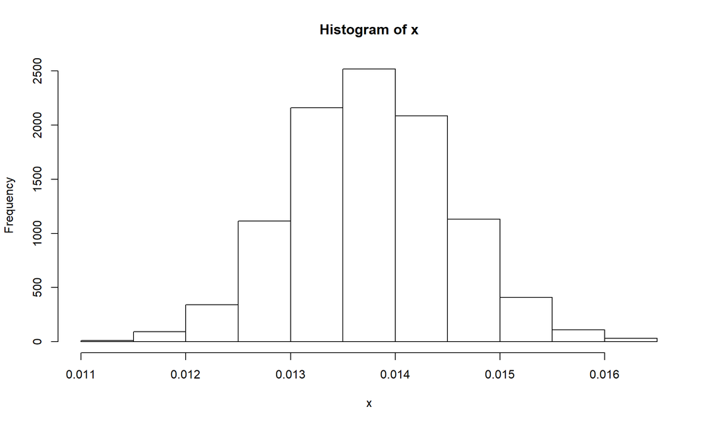

```r
# sum((c(mean(x),quantile(x,c(.025,.975)))*100-CFR_esti*100)^2)
hist(x)
```

```r
post_CFR <- x
```

get ascertainment

```r
# do inference
rho_it<-array(NA, dim = c(nrow(I), N_geo,n_post))
summary_rho <- list(median = temp,
                    low = temp,
                    high = temp)
for (i in 1:nrow(I)){
  for (j in 1:N_geo){

    rho_it[i,j,] <- post_CFR/r_it[i,j,]
    rho_it[i,j,which(rho_it[i,j,]>1)] <- 1
    summary_rho$median[i,j+1] <- median(rho_it[i,j,],na.rm = TRUE)
    summary_rho$low[i,j+1] <- quantile(rho_it[i,j,], 0.025,na.rm = TRUE)
    summary_rho$high[i,j+1] <- quantile(rho_it[i,j,], 0.975,na.rm=TRUE)

  }
}
```

# true epidemic size

prior to t-mu_delta

```r
f <- seq(1,nrow(D)-round(mu_delta))

I_true <- array(NA, dim = c(nrow(I), N_geo,n_post))
summary_I_true <- list(median = temp,
                    low = temp,
                    high = temp)
for (i in f){
  for (j in 1:N_geo){
    I_true[i,j,] <- D[i+round(mu_delta),j+1] + rnbinom(n = n_post, size = D[i+round(mu_delta),j+1] , prob = post_CFR)
    summary_I_true$median[i,j+1] <- median(I_true[i,j,],na.rm = TRUE)
    summary_I_true$low[i,j+1] <- quantile(I_true[i,j,],.025,na.rm = TRUE)
    summary_I_true$high[i,j+1] <- quantile(I_true[i,j,],.975,na.rm=TRUE)
  }
}
```

post to t-mu_delta

```r
f <- seq(nrow(D)-round(mu_delta)+1,nrow(D))

for (i in f){
  for (j in 1:N_geo){
    I_true[i,j,] <- I[i,j+1] + rnbinom(n = n_post, size = I[i,j+1] , prob = rho_it[i,j,])
    summary_I_true$median[i,j+1] <- median(I_true[i,j,],na.rm = TRUE)
    summary_I_true$low[i,j+1] <- quantile(I_true[i,j,],.025,na.rm = TRUE)
    summary_I_true$high[i,j+1] <- quantile(I_true[i,j,],.975,na.rm=TRUE)
  }
}
```

# results for the table

nw reporting measures for the last week (7 days)

```r
last_week <- data.frame(country = country,
                       median = rep(NA,N_geo),
                        low = rep(NA,N_geo),
                        high = rep(NA,N_geo))
for (i in 1:N_geo){
  last_week[i,c(2,3,4)] <- quantile(colSums(I_true[(nrow(D)-7+1):nrow(D),i,],na.rm=TRUE),c(.5,.025,.975),na.rm=TRUE)
}

# summary
summary_14days <- data.frame(
    country = country,
    deaths_to_reported_ratio = glue::glue(
        "{round(summary_r$median[nrow(D),-1], 3) }",
        " ({round(summary_r$low[nrow(D),-1],3)} - {round(summary_r$high[nrow(D),-1],3)})",
    ),
    estimated_reporting = glue::glue(
        "{scales::percent(as.numeric(round(summary_rho$median[nrow(D),-1], 3)), accuracy = 0.1)}",
        " ({scales::percent(as.numeric(round(summary_rho$low[nrow(D),-1],3)), accuracy = 0.1)} - {scales::percent(as.numeric(round(summary_rho$high[nrow(D),-1],3)), accuracy = 0.1)})",
    ),
    factor_to_real_size = glue::glue(
        "{round(1/summary_rho$median[nrow(D),-1], 2)}",
        " ({round(1/summary_rho$high[nrow(D),-1], 2)} - {round(1/summary_rho$low[nrow(D),-1], 2)})",
    ),
    Observed_case_last_week = colSums(tail(I[,-1],7)),
    Predicted_True_case_last_week = glue::glue(
        "{prettyNum(signif(last_week$median,digits = 3), big.mark = ",")} ",
        "({prettyNum(signif(last_week$low,digits = 3), big.mark = ",")}",
        " - {prettyNum(signif(last_week$high,digits = 3), big.mark = ",")})"
        )
)

summary_14days <- summary_14days[order(temp[,1],decreasing = TRUE),]
## TODO check why we have NAs
summary_14days <- na.omit(summary_14days)
readr::write_csv(
    x = summary_14days,
    path = paste0('../Team.output/summary_DeathToRepoted_14days_',date_week_finishing,'.csv')
)
```

```r
## unformatted
f <- function(df, col) {

    df <- tidyr::gather(df, country, !!col)
    df[[col]] <- round(df[[col]], 3)
    out <- data.frame(df[[col]])
    colnames(out) <- col
    out
}

unformatted_summary_14days <- data.frame(
    country = country,
    Observed_case_last_week = colSums(tail(I[,-1],7)),
    Predicted_True_case_last_week_50 = last_week$median,
    Predicted_True_case_last_week_025 = last_week$low,
    Predicted_True_case_last_week_975 = last_week$high
    )

tmp <- list(
    f(summary_r$median[nrow(D),-1], "deaths_to_reported_ratio_50"),
    f(summary_r$low[nrow(D),-1], "deaths_to_reported_ratio_025"),
    f(summary_r$high[nrow(D),-1], "deaths_to_reported_ratio_975"),
    f(summary_rho$median[nrow(D),-1], "estimated_reporting_50"),
    f(summary_rho$low[nrow(D),-1], "estimated_reporting_025"),
    f(summary_rho$high[nrow(D),-1], "estimated_reporting_975")
)

tmp <- do.call(what = 'cbind', args = tmp)
unformatted_summary_14days <- cbind(unformatted_summary_14days, tmp)
readr::write_csv(
    x = unformatted_summary_14days,
    path = paste0('../Team.output/unformatted_summary_DeathToRepoted_14days_',date_week_finishing,'.csv')
)
```

# forecast death next week based on the above

```r
I_lastweek <- colSums(tail(I[,-1],7))/7
sd_lastweek <- (apply(tail(I[,-1],7),2,sd))

cbind(I_lastweek,sd_lastweek)
```

```
##                           I_lastweek sd_lastweek
## Belgium                    902.71429   530.20647
## Brazil                     396.57143   103.51144
## Canada                     593.57143   425.86221
## China                      120.42857    18.88436
## Denmark                    125.00000    41.74526
## France                    3302.28571  1044.88049
## Germany                   4440.57143  1378.34343
## Greece                      75.85714    15.95231
## Indonesia                  100.71429    30.22534
## Iran                      2114.00000   760.08618
## Italy                     5556.28571   499.30142
## Japan                       92.42857    55.52134
## Netherlands                875.85714   256.36070
## Philippines                 99.28571    82.78227
## Portugal                   555.71429   217.31139
## South_Korea                 98.00000    26.08320
## Spain                     6760.28571  1946.18582
## Sweden                     243.00000    93.58953
## Switzerland               1010.71429   192.99112
## Turkey                     922.14286   737.57495
## United_Kingdom            1724.42857   821.01073
## United_States_of_America 13988.28571  4674.61195
```

```r
Predictions <- list()
date_pre <- date_week_finishing + seq(1,7,by=1)

for( i in 1:length(country)){


  repo <- matrix(sample(x = r_it[nrow(I),i,],size = 7*n_post,replace = TRUE),nrow = n_post, ncol = 7)
  I_aug <- matrix(rpois(n = 7*n_post, lambda = I_lastweek[i]),nrow = n_post, ncol = 7)

  param <- epitrix::gamma_mucv2shapescale(mu = I_lastweek[i], cv = sd_lastweek[i]/I_lastweek[i])
  # I_aug <- matrix(rpois(n = 7*n_post, lambda = I_lastweek[i]),nrow = n_post, ncol = 7)
  I_aug <- matrix(rgamma(n = 7*n_post, shape = param$shape, scale = param$scale),nrow = n_post, ncol = 7)


  I_old <- matrix( tail(I[,i+1],w_delta$SItrunc), nrow = n_post, ncol = w_delta$SItrunc, byrow = TRUE )
  I_augm <- cbind(I_old,I_aug)

  weighted_I_augm <- matrix(NA, nrow = n_post, ncol = ncol(I_augm))
  ws <- rev(w_delta$dist)

  for (j in 2:ncol(I_augm)){
    f <- max(c(1,(j-w_delta$SItrunc)))
    weighted_I_augm[,j] <- ((I_augm[,f:j])%*%ws[((SItrunc+1)-(j-f)):(SItrunc+1)])

  }
  weighted_I_augm <- weighted_I_augm[,(ncol(weighted_I_augm)-7+1) : (ncol(weighted_I_augm))]
  d_exp <- data.frame(matrix(NA,nrow = n_post,7))
  for (k in 1:7){
    d_exp[,k] <- rbinom(n = n_post, size = round(weighted_I_augm[,k]), prob = repo[,k])
  }
  names(d_exp) <- as.character(date_pre)
  Predictions[[as.character(country[i])]][[1]] <- d_exp
  Predictions[[as.character(country[i])]][[2]] <- d_exp

}
```

Combine results:

```r
temp <- list(rep(NA, n_post),rep(NA, n_post))
Rt_last <-list()
for (i in 1:N_geo){
  Rt_last[[as.character(country[i])]] <- temp
}


Std_results <- list(I_active_transmission = d$I_active_transmission,
                    D_active_transmission = d$D_active_transmission,
                    Country = d$Country,
                    Rt_last = Rt_last,
                    Predictions = Predictions)

saveRDS(object = Std_results,
        file = paste0('RData/DeCa_Std_results_week_end_',date_week_finishing,'.rds' ))
```